# R Notebook

[output not shown]

[output cut: 1513 more lines]

[output not shown]

[output cut: 86 more lines]

```
## empty rows removed
```

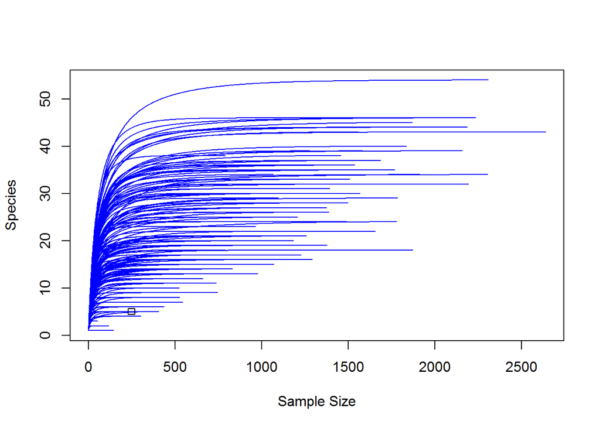

We see that alot of our samples start to plataeu around ~250 reads. And so we will now proceed to do some our quality control step.

```r
ghsoilspecies_16S_edited <- subset(gh_soil_16S_rdp,total > 250 & Stem_width > 0 & Soil_type != "Sterile")
```

Now we need to normalize our counts:

```
## *** No convergence -- monoMDS stopping criteria:
##     20: stress ratio > sratmax
```

Stress value is 0.23 which is okay. Its not ideal. Now we proceed to plot our NMDS plot:

[output not shown]

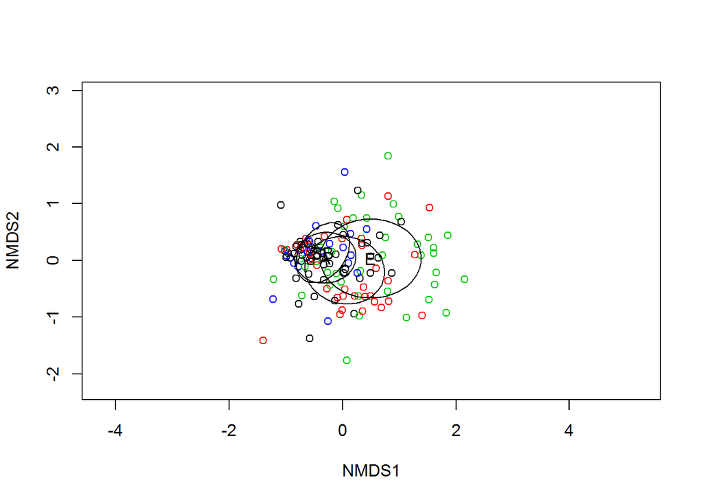

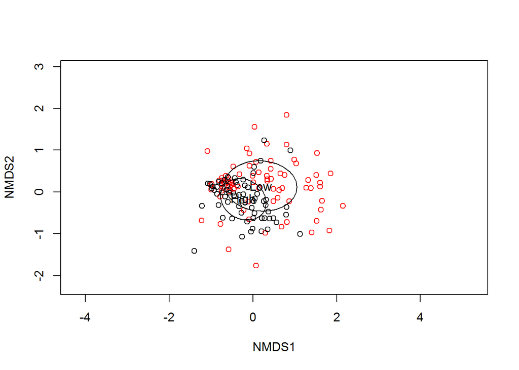

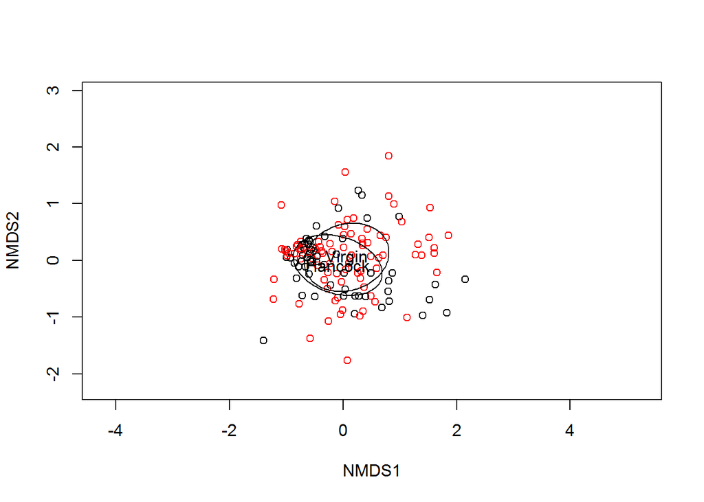

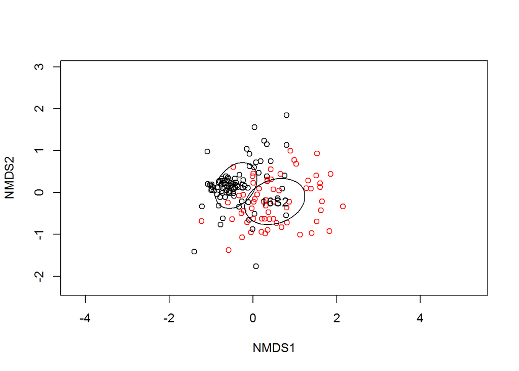

This plot is of everything!

Now let’s use ggplot2 instead of base R to make our plots:

```r
#library(ggplot2)
#coords <- as.data.frame(scores(ghsoilmds))
#plot(coords$NMDS2 ~ coords$NMDS1)
#meta_coords <- bind_cols(ghsoil16S[,1:23],coords)
#bac_plot <- ggplot(meta_coords,aes(NMDS1, NMDS2))+
  #geom_point(size=2.5, alpha=0.3, aes(shape = meta_coords$Species))+
  #stat_ellipse(geom = "polygon", data=meta_coords, #aes(x=NMDS1,y=NMDS2,fill=Species,group=Species), alpha=0.30)+
  #scale_colour_manual(values=c("A" = "red", "C" = "blue", "SB" = "green", "E" = "yellow"))
```

```r
fit_gh16S <- adonis(ghsoil16S[,24:1507] ~ Nutrient*timepoint*Soil_type*Species, data = ghsoil16S, permutations = 999)
fit_gh16S
```

```
##
## Call:
## adonis(formula = ghsoil16S[, 24:1507] ~ Nutrient * timepoint *      Soil_type * Species, data = ghsoil16S, permutations = 999)
##
## Permutation: free
## Number of permutations: 999
##
## Terms added sequentially (first to last)
##
##                                       Df SumsOfSqs MeanSqs F.Model      R2
## Nutrient                               1     1.291  1.2910  8.1072 0.04074
## timepoint                              1     4.420  4.4198 27.7563 0.13948
## Soil_type                              1     0.321  0.3206  2.0132 0.01012
## Species                                3     1.978  0.6593  4.1405 0.06242
## Nutrient:timepoint                     1     0.528  0.5281  3.3162 0.01666
## Nutrient:Soil_type                     1     0.265  0.2648  1.6627 0.00836
## timepoint:Soil_type                    1     0.222  0.2219  1.3938 0.00700
## Nutrient:Species                       3     0.879  0.2930  1.8401 0.02774
## timepoint:Species                      3     0.633  0.2108  1.3241 0.01996
## Soil_type:Species                      3     0.746  0.2487  1.5616 0.02354
## Nutrient:timepoint:Soil_type           1     0.390  0.3900  2.4494 0.01231
## Nutrient:timepoint:Species             3     0.580  0.1933  1.2141 0.01830
## Nutrient:Soil_type:Species             3     0.545  0.1816  1.1407 0.01720
## timepoint:Soil_type:Species            3     0.574  0.1913  1.2012 0.01811
## Nutrient:timepoint:Soil_type:Species   2     0.324  0.1621  1.0178 0.01023
## Residuals                            113    17.994  0.1592         0.56784
## Total                                143    31.688                 1.00000
##                                      Pr(>F)
## Nutrient                              0.001 ***
## timepoint                             0.001 ***
## Soil_type                             0.077 .
## Species                               0.001 ***
## Nutrient:timepoint                    0.006 **
## Nutrient:Soil_type                    0.134
## timepoint:Soil_type                   0.206
## Nutrient:Species                      0.040 *
## timepoint:Species                     0.188
## Soil_type:Species                     0.065 .
## Nutrient:timepoint:Soil_type          0.030 *
## Nutrient:timepoint:Species            0.267
## Nutrient:Soil_type:Species            0.297
## timepoint:Soil_type:Species           0.272
## Nutrient:timepoint:Soil_type:Species  0.416
## Residuals
## Total
## ---
## Signif. codes:  0 '***' 0.001 '**' 0.01 '*' 0.05 '.' 0.1 ' ' 1
```

**Diversity analysis**

Make table that includes shannon index column

```r
library(tidyverse)
diversity <- diversity(gh_soil_16S_rdp[23:1502],index="shannon")
div_col <- as.data.frame(diversity)
div_table <- gh_soil_16S_rdp[1:22]
metadata <- bind_cols(div_table,div_col)
gh_div <- bind_cols(metadata,table1)
```

```r
ghsoilspecies_16S_edited <- subset(gh_div,total > 200 & Stem_width > 0 & Soil_type != "Sterile")
ghsoilspecies_16S_std = decostand(ghsoilspecies_16S_edited[,24:1503], method = "total")
ghsoil16S = cbind(ghsoilspecies_16S_edited[,1:23],ghsoilspecies_16S_std)
ghsoilmds <- metaMDS(ghsoilspecies_16S_std)
```

```
## *** No convergence -- monoMDS stopping criteria:
##      1: no. of iterations >= maxit
##     19: stress ratio > sratmax
```

Now we do some statistics with diversity:

```r
library(lmerTest)
library(lme4)
library(MASS)
library(car)
library(lsmeans)
ghsoil16S$timepoint = as.factor(ghsoil16S$timepoint)

div_test <- lmer(diversity ~ timepoint + Nutrient + Species*Soil_type + (1|Variety), data = ghsoil16S)

summary(div_test)
```

```
## Linear mixed model fit by REML. t-tests use Satterthwaite's method [
## lmerModLmerTest]
## Formula: diversity ~ timepoint + Nutrient + Species * Soil_type + (1 |
##     Variety)
##    Data: ghsoil16S
##
## REML criterion at convergence: 285.9
##
## Scaled residuals:
##      Min       1Q   Median       3Q      Max
## -2.87447 -0.45122  0.02914  0.64034  1.94259
##
## Random effects:
##  Groups   Name        Variance Std.Dev.
##  Variety  (Intercept) 0.002158 0.04646
##  Residual             0.367710 0.60639
## Number of obs: 149, groups:  Variety, 17
##
## Fixed effects:
##                            Estimate Std. Error        df t value Pr(>|t|)
## (Intercept)                 2.24798    0.14062  37.31764  15.986  < 2e-16
## timepoint16S2               0.40091    0.10229 138.13578   3.919 0.000139
## NutrientLow                -0.11367    0.10033 135.66370  -1.133 0.259204
## SpeciesC                   -0.08745    0.19782  41.07257  -0.442 0.660738
## SpeciesE                    0.35554    0.21017  32.45325   1.692 0.100283
## SpeciesSB                  -0.25766    0.28071  72.81980  -0.918 0.361705
## Soil_typeVirgin            -0.18465    0.17484 136.41934  -1.056 0.292788
## SpeciesC:Soil_typeVirgin    0.33050    0.26250 134.21094   1.259 0.210195
## SpeciesE:Soil_typeVirgin    0.03953    0.26745 138.99482   0.148 0.882711
## SpeciesSB:Soil_typeVirgin   0.35169    0.34397 133.79694   1.022 0.308411
##
## (Intercept)               ***
## timepoint16S2             ***
## NutrientLow
## SpeciesC
## SpeciesE
## SpeciesSB
## Soil_typeVirgin
## SpeciesC:Soil_typeVirgin
## SpeciesE:Soil_typeVirgin
## SpeciesSB:Soil_typeVirgin
## ---
## Signif. codes:  0 '***' 0.001 '**' 0.01 '*' 0.05 '.' 0.1 ' ' 1
##
## Correlation of Fixed Effects:
##             (Intr) tm16S2 NtrntL SpecsC SpecsE SpcsSB Sl_tyV SC:S_V SE:S_V
## timepnt16S2 -0.223
## NutrientLow -0.343  0.005
## SpeciesC    -0.558 -0.115 -0.026
## SpeciesE    -0.509 -0.098 -0.080  0.410
## SpeciesSB   -0.426  0.049 -0.007  0.291  0.275
## Sol_typVrgn -0.612 -0.093 -0.057  0.476  0.450  0.323
## SpcsC:Sl_tV  0.395  0.116  0.041 -0.740 -0.305 -0.212 -0.671
## SpcsE:Sl_tV  0.387  0.077  0.064 -0.314 -0.768 -0.210 -0.657  0.442
## SpcsSB:Sl_V  0.333 -0.051  0.029 -0.230 -0.219 -0.804 -0.499  0.330  0.326
```

```r
anova(div_test)
```

|  | Sum Sq | Mean Sq | NumDF | DenDF | F value | Pr(>F) |
| --- | --- | --- | --- | --- | --- | --- |
| timepoint | 5.6482983856 | 5.6482983856 | 1 | 138.13578 | 15.360744543 | 0.0001391966 |
| Nutrient | 0.4720419607 | 0.4720419607 | 1 | 135.66370 | 1.283734583 | 0.2592042204 |
| Species | 3.5656695620 | 1.1885565207 | 3 | 11.26834 | 3.232320930 | 0.0634963261 |
| Soil_type | 0.0005299341 | 0.0005299341 | 1 | 135.28685 | 0.001441174 | 0.9697733023 |
| Species:Soil_type | 0.8702088797 | 0.2900696266 | 3 | 136.58102 | 0.788854471 | 0.5020955042 |

```r
div_rg1 <- ref.grid(div_test)
summary(div_rg1)
```

|  | timepoint | Nutrient | Species | Soil_type | prediction | SE | df |
| --- | --- | --- | --- | --- | --- | --- | --- |
| 1 | 16S | High | A | Hancock | 2.247975 | 0.1424514 | 42.05156 |
| 2 | 16S2 | High | A | Hancock | 2.648887 | 0.1563208 | 52.10248 |
| 3 | 16S | Low | A | Hancock | 2.134302 | 0.1436472 | 45.73205 |
| 4 | 16S2 | Low | A | Hancock | 2.535214 | 0.1581249 | 54.16244 |
| 5 | 16S | High | C | Hancock | 2.160522 | 0.1675014 | 79.81050 |
| 6 | 16S2 | High | C | Hancock | 2.561433 | 0.1663841 | 69.42735 |
| 7 | 16S | Low | C | Hancock | 2.046848 | 0.1654801 | 77.52834 |
| 8 | 16S2 | Low | C | Hancock | 2.447760 | 0.1650327 | 65.20631 |
| 9 | 16S | High | E | Hancock | 2.603519 | 0.1891012 | 47.52351 |
| 10 | 16S2 | High | E | Hancock | 3.004430 | 0.1872737 | 56.06538 |

[output cut: 22 more lines]

```r
lsmeans(div_test,"Species")
```

```
## NOTE: Results may be misleading due to involvement in interactions
```

```
##  Species lsmean     SE    df lower.CL upper.CL
##  A         2.30 0.0916  9.07     2.09     2.51
##  C         2.38 0.1007 13.50     2.16     2.59
##  E         2.67 0.1056 10.38     2.44     2.91
##  SB        2.22 0.1531 24.59     1.90     2.53
##
## Results are averaged over the levels of: timepoint, Nutrient, Soil_type
## Degrees-of-freedom method: kenward-roger
## Confidence level used: 0.95
```

### timepoint is a strong effect so need to split it out. So we will need to recalculate lSmeans for shannon subsetting for TP1 and TP2.

Looking at the LSMEANs Elite/Modern genotypes recruit a greater diversity of microbes followed by landraces and Wild genotype (S. Berthalti).

```r
lsmeans(div_test,"timepoint")
```

```
##  timepoint lsmean     SE   df lower.CL upper.CL
##  16S         2.19 0.0719 30.4     2.04     2.34
##  16S2        2.59 0.0836 47.0     2.42     2.76
##
## Results are averaged over the levels of: Nutrient, Species, Soil_type
## Degrees-of-freedom method: kenward-roger
## Confidence level used: 0.95
```

Timepoint 2 has a greater diversity of microbes than timepoint 1. Now lets just try to remove nutrient and also timepoint factors:

```r
ghsoil16S$timepoint = as.factor(ghsoil16S$timepoint)

div_test <- lmer(diversity ~ Nutrient*Species*Soil_type + (1|Variety), data = subset(ghsoil16S, timepoint =="16S"))
```

```
## boundary (singular) fit: see ?isSingular
```

```r
summary(div_test)
```

```
## Linear mixed model fit by REML. t-tests use Satterthwaite's method [
## lmerModLmerTest]
## Formula: diversity ~ Nutrient * Species * Soil_type + (1 | Variety)
##    Data: subset(ghsoil16S, timepoint == "16S")
##
## REML criterion at convergence: 171.2
##
## Scaled residuals:
##      Min       1Q   Median       3Q      Max
## -2.14140 -0.47880 -0.02787  0.60756  2.07107
##
## Random effects:
##  Groups   Name        Variance Std.Dev.
##  Variety  (Intercept) 0.0000   0.0000
##  Residual             0.4859   0.6971
## Number of obs: 85, groups:  Variety, 17
##
## Fixed effects:
##                                       Estimate Std. Error      df t value
## (Intercept)                             2.2883     0.2635 69.0000   8.685
## NutrientLow                            -0.2978     0.3513 69.0000  -0.848
## SpeciesC                               -0.3167     0.4810 69.0000  -0.658
## SpeciesE                                0.2404     0.4369 69.0000   0.550
## SpeciesSB                              -0.7544     0.4810 69.0000  -1.568
## Soil_typeVirgin                        -0.2465     0.3878 69.0000  -0.636
## NutrientLow:SpeciesC                    0.4846     0.6185 69.0000   0.783
## NutrientLow:SpeciesE                    0.4264     0.6378 69.0000   0.669
## NutrientLow:SpeciesSB                   0.9119     0.7269 69.0000   1.255
## NutrientLow:Soil_typeVirgin             0.1514     0.5149 69.0000   0.294
## SpeciesC:Soil_typeVirgin                0.2506     0.6400 69.0000   0.392
## SpeciesE:Soil_typeVirgin                0.2386     0.5842 69.0000   0.408
## SpeciesSB:Soil_typeVirgin               1.0309     0.6587 69.0000   1.565
## NutrientLow:SpeciesC:Soil_typeVirgin   -0.1040     0.8219 69.0000  -0.127
## NutrientLow:SpeciesE:Soil_typeVirgin   -0.1570     0.8291 69.0000  -0.189
## NutrientLow:SpeciesSB:Soil_typeVirgin  -0.8494     0.9765 69.0000  -0.870
##                                       Pr(>|t|)
## (Intercept)                           1.12e-12 ***
## NutrientLow                              0.399
## SpeciesC                                 0.512
## SpeciesE                                 0.584
## SpeciesSB                                0.121
## Soil_typeVirgin                          0.527
## NutrientLow:SpeciesC                     0.436
## NutrientLow:SpeciesE                     0.506
## NutrientLow:SpeciesSB                    0.214
## NutrientLow:Soil_typeVirgin              0.770
## SpeciesC:Soil_typeVirgin                 0.697
## SpeciesE:Soil_typeVirgin                 0.684
## SpeciesSB:Soil_typeVirgin                0.122
## NutrientLow:SpeciesC:Soil_typeVirgin     0.900
## NutrientLow:SpeciesE:Soil_typeVirgin     0.850
## NutrientLow:SpeciesSB:Soil_typeVirgin    0.387
## ---
## Signif. codes:  0 '***' 0.001 '**' 0.01 '*' 0.05 '.' 0.1 ' ' 1
```

```
##
## Correlation matrix not shown by default, as p = 16 > 12.
## Use print(x, correlation=TRUE)  or
##     vcov(x)        if you need it
```

```
## convergence code: 0
## boundary (singular) fit: see ?isSingular
```

```r
anova(div_test)
```

|  | Sum Sq | Mean Sq | NumDF | DenDF | F value | Pr(>F) |
| --- | --- | --- | --- | --- | --- | --- |
| Nutrient | 0.15651543 | 0.15651543 | 1 | 69 | 0.3221153 | 0.57218125 |
| Species | 3.88108464 | 1.29369488 | 3 | 69 | 2.6624784 | 0.05475179 |
| Soil_type | 0.08633401 | 0.08633401 | 1 | 69 | 0.1776790 | 0.67468578 |
| Nutrient:Species | 0.81789802 | 0.27263267 | 3 | 69 | 0.5610895 | 0.64250177 |
| Nutrient:Soil_type | 0.06933080 | 0.06933080 | 1 | 69 | 0.1426857 | 0.70678503 |
| Species:Soil_type | 0.75313050 | 0.25104350 | 3 | 69 | 0.5166581 | 0.67218920 |
| Nutrient:Species:Soil_type | 0.38297719 | 0.12765906 | 3 | 69 | 0.2627277 | 0.85201141 |

```r
div_rg1 <- ref.grid(div_test)
summary(div_rg1)
```

|  | Nutrient | Species | Soil_type | prediction | SE | df |
| --- | --- | --- | --- | --- | --- | --- |
| 1 | High | A | Hancock | 2.288255 | 0.2865426 | 20.47782 |
| 2 | Low | A | Hancock | 1.990442 | 0.2332896 | 50.31817 |
| 3 | High | C | Hancock | 1.971523 | 0.4071744 | 68.05237 |
| 4 | Low | C | Hancock | 2.158271 | 0.3216639 | 42.84637 |
| 5 | High | E | Hancock | 2.528616 | 0.3600981 | 47.58986 |
| 6 | Low | E | Hancock | 2.657214 | 0.4175538 | 55.79475 |
| 7 | High | SB | Hancock | 1.533905 | 0.4024503 | 68.05237 |
| 8 | Low | SB | Hancock | 2.148030 | 0.4959811 | 68.05237 |
| 9 | High | A | Virgin | 2.041755 | 0.2862910 | 63.22420 |
| 10 | Low | A | Virgin | 1.895332 | 0.2514605 | 41.70816 |

[output cut: 6 more lines]

```r
lsmeans(div_test,"Species")
```

```
## NOTE: Results may be misleading due to involvement in interactions
```

```
##  Species lsmean    SE    df lower.CL upper.CL
##  A         2.05 0.133  5.79     1.73     2.38
##  C         2.08 0.161 16.70     1.74     2.42
##  E         2.59 0.169  7.88     2.20     2.98
##  SB        2.06 0.214 11.78     1.59     2.53
##
## Results are averaged over the levels of: Nutrient, Soil_type
## Degrees-of-freedom method: kenward-roger
## Confidence level used: 0.95
```

According to ANOVA, we see that species is weakly causing differences in Shannon diversity. Interestinly enough, nutrients isn’t effecting the microbial diversity at first timepoint.

how about just timepoint 2:

```r
div_test <- lmer(diversity ~ Nutrient*Species*Soil_type + (1|Variety), data = subset(ghsoil16S, timepoint =="16S2"))
```

```
## fixed-effect model matrix is rank deficient so dropping 1 column / coefficient
```

```r
summary(div_test)
```

```
## Linear mixed model fit by REML. t-tests use Satterthwaite's method [
## lmerModLmerTest]
## Formula: diversity ~ Nutrient * Species * Soil_type + (1 | Variety)
##    Data: subset(ghsoil16S, timepoint == "16S2")
##
## REML criterion at convergence: 90.9
##
## Scaled residuals:
##      Min       1Q   Median       3Q      Max
## -2.84072 -0.49728  0.00975  0.55821  1.86960
##
## Random effects:
##  Groups   Name        Variance Std.Dev.
##  Variety  (Intercept) 0.009343 0.09666
##  Residual             0.244576 0.49455
## Number of obs: 64, groups:  Variety, 16
##
## Fixed effects:
##                                      Estimate Std. Error       df t value
## (Intercept)                           2.75101    0.22836 39.30153  12.047
## NutrientLow                           0.04911    0.41633 46.49941   0.118
## SpeciesC                             -0.17136    0.32398 36.79734  -0.529
## SpeciesE                             -0.02808    0.55237 48.20647  -0.051
## SpeciesSB                             0.39343    0.78162 48.99648   0.503
## Soil_typeVirgin                      -0.03889    0.31921 47.98655  -0.122
## NutrientLow:SpeciesC                 -0.19161    0.53388 46.65311  -0.359
## NutrientLow:SpeciesE                  0.12848    0.67923 45.97005   0.189
## NutrientLow:SpeciesSB                -0.06488    0.48232 48.94919  -0.135
## NutrientLow:Soil_typeVirgin          -0.50190    0.50824 46.66496  -0.988
## SpeciesC:Soil_typeVirgin              0.39432    0.43879 48.91399   0.899
## SpeciesE:Soil_typeVirgin              0.09613    0.64389 48.89706   0.149
## SpeciesSB:Soil_typeVirgin            -0.48214    0.68858 48.74179  -0.700
## NutrientLow:SpeciesC:Soil_typeVirgin  0.36139    0.70413 47.54294   0.513
## NutrientLow:SpeciesE:Soil_typeVirgin  0.00778    0.79840 45.39140   0.010
##                                      Pr(>|t|)
## (Intercept)                          9.07e-15 ***
## NutrientLow                             0.907
## SpeciesC                                0.600
## SpeciesE                                0.960
## SpeciesSB                               0.617
## Soil_typeVirgin                         0.904
## NutrientLow:SpeciesC                    0.721
## NutrientLow:SpeciesE                    0.851
## NutrientLow:SpeciesSB                   0.894
## NutrientLow:Soil_typeVirgin             0.328
## SpeciesC:Soil_typeVirgin                0.373
## SpeciesE:Soil_typeVirgin                0.882
## SpeciesSB:Soil_typeVirgin               0.487
## NutrientLow:SpeciesC:Soil_typeVirgin    0.610
## NutrientLow:SpeciesE:Soil_typeVirgin    0.992
## ---
## Signif. codes:  0 '***' 0.001 '**' 0.01 '*' 0.05 '.' 0.1 ' ' 1
```

```
##
## Correlation matrix not shown by default, as p = 15 > 12.
## Use print(x, correlation=TRUE)  or
##     vcov(x)        if you need it
```

```
## fit warnings:
## fixed-effect model matrix is rank deficient so dropping 1 column / coefficient
```

```r
anova(div_test)
```

```
## Missing cells for: NutrientHigh:SpeciesSB:Soil_typeHancock.
## Interpret type III hypotheses with care.
```

|  | Sum Sq | Mean Sq | NumDF | DenDF | F value | Pr(>F) |
| --- | --- | --- | --- | --- | --- | --- |
| Nutrient | 0.42512394 | 0.42512394 | 1 | 47.53573 | 1.73820782 | 0.1936835 |
| Species | 0.04357838 | 0.01452613 | 3 | 17.49029 | 0.05939309 | 0.9804066 |
| Soil_type | 0.41009263 | 0.41009263 | 1 | 48.99441 | 1.67674918 | 0.2014261 |
| Nutrient:Species | 0.07665386 | 0.02555129 | 3 | 47.68090 | 0.10447176 | 0.9570616 |
| Nutrient:Soil_type | 0.36106834 | 0.36106834 | 1 | 46.36101 | 1.47630315 | 0.2305058 |
| Species:Soil_type | 1.12980136 | 0.37660045 | 3 | 48.72436 | 1.53980944 | 0.2160728 |
| Nutrient:Species:Soil_type | 0.08027291 | 0.04013645 | 2 | 46.53641 | 0.16410625 | 0.8491408 |

```r
div_rg1 <- ref.grid(div_test)
summary(div_rg1)
```

|  | Nutrient | Species | Soil_type | prediction | SE | df |
| --- | --- | --- | --- | --- | --- | --- |
| 1 | High | A | Hancock | 2.751012 | 0.2351995 | 34.62641 |
| 2 | Low | A | Hancock | 2.800124 | 0.3656150 | 48.31966 |
| 3 | High | C | Hancock | 2.579649 | 0.2395919 | 28.49767 |
| 4 | Low | C | Hancock | 2.437154 | 0.2581593 | 39.55330 |
| 5 | High | E | Hancock | 2.722931 | 0.5239826 | 48.77541 |
| 6 | Low | E | Hancock | 2.900526 | 0.2148727 | 30.58888 |
| 7 | High | SB | Hancock | NA | NA | NA |
| 8 | Low | SB | Hancock | 3.128675 | 0.5151191 | 48.12470 |
| 9 | High | A | Virgin | 2.712117 | 0.2393574 | 27.93681 |
| 10 | Low | A | Virgin | 2.259333 | 0.1977219 | 32.95846 |

[output cut: 6 more lines]

```r
lsmeans(div_test,"Species")
```

```
## NOTE: Results may be misleading due to involvement in interactions
```

```
##  Species lsmean    SE   df lower.CL upper.CL
##  A         2.63 0.138 10.9     2.33     2.93
##  C         2.65 0.139  5.4     2.30     3.00
##  E         2.72 0.169 14.0     2.35     3.08
##  SB      nonEst    NA   NA       NA       NA
##
## Results are averaged over the levels of: Nutrient, Soil_type
## Degrees-of-freedom method: kenward-roger
## Confidence level used: 0.95
```

**Now how about if we did a subset for just timepoint 1:**

```r
ghsoilspecies_16S_TP1 <- subset(ghsoil16S, timepoint == "16S")
ghsoilmds = metaMDS(ghsoilspecies_16S_TP1[,24:1503])
```

```
## *** No convergence -- monoMDS stopping criteria:
##     20: stress ratio > sratmax
```

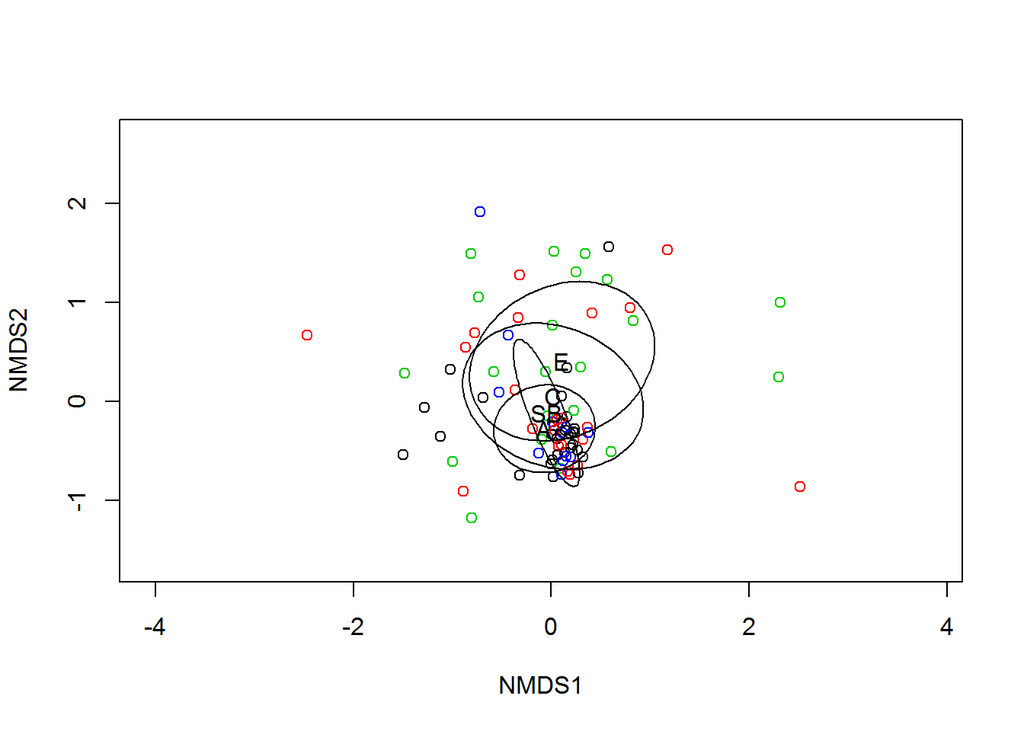

```r
plot(ghsoilmds, display = "species", type= "n")
points(ghsoilmds,display = "sites", col = as.numeric(ghsoilspecies_16S_TP1$Species))
ordiellipse(ghsoilmds, ghsoilspecies_16S_TP1$Species, label = TRUE)
```

```r
fit_gh16S <- adonis(ghsoilspecies_16S_TP1[23:1503] ~ Nutrient*Soil_type*Species, data = ghsoilspecies_16S_TP1, permutations = 999)
fit_gh16S
```

```
##
## Call:
## adonis(formula = ghsoilspecies_16S_TP1[23:1503] ~ Nutrient *      Soil_type * Species, data = ghsoilspecies_16S_TP1, permutations = 999)
##
## Permutation: free
## Number of permutations: 999
##
## Terms added sequentially (first to last)
##
##                            Df SumsOfSqs  MeanSqs F.Model      R2 Pr(>F)
## Nutrient                    1    0.0526 0.052597 0.70404 0.00814  0.597
## Soil_type                   1    0.1132 0.113215 1.51544 0.01752  0.155
## Species                     3    0.4834 0.161117 2.15664 0.07480  0.015 *
## Nutrient:Soil_type          1    0.0601 0.060093 0.80438 0.00930  0.469
## Nutrient:Species            3    0.2034 0.067802 0.90757 0.03148  0.513
## Soil_type:Species           3    0.1672 0.055723 0.74588 0.02587  0.729
## Nutrient:Soil_type:Species  3    0.2273 0.075759 1.01407 0.03517  0.394
## Residuals                  69    5.1548 0.074707         0.79772
## Total                      84    6.4619                  1.00000
## ---
## Signif. codes:  0 '***' 0.001 '**' 0.01 '*' 0.05 '.' 0.1 ' ' 1
```

Subsetting for timepoint 1 any subsetting see that species was the only thing that was statistically significant in determining microbial composition. We do see a interesting result in that Elites look less restrictive in microbiomes than more ancestral genotypes

## Now for timepoint #2:

```r
ghsoilspecies_16S_TP2 <- subset(ghsoil16S, timepoint == "16S2")
ghsoilmds = metaMDS(ghsoilspecies_16S_TP2[24:1503])
```

```
## *** Solution reached
```

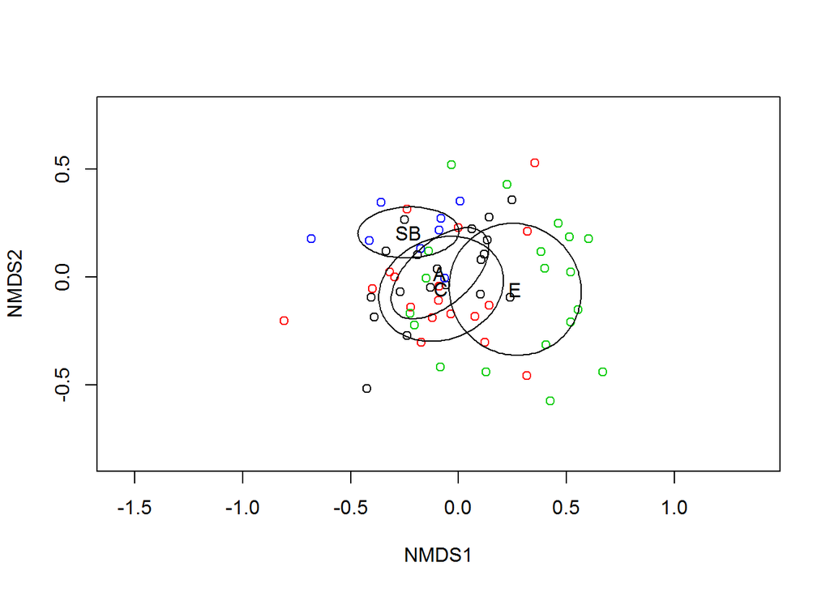

```r
plot(ghsoilmds, display = "species", type= "n")
points(ghsoilmds,display = "sites", col = as.numeric(ghsoilspecies_16S_TP2$Species))
ordiellipse(ghsoilmds, ghsoilspecies_16S_TP2$Species, label = T)
```

It seems that @ timepoint 2 see communities start to diverge a bit more in contrast to timepoint 1. They are start to look less similar.

```r
fit_gh16S <- adonis(ghsoilspecies_16S_TP2[24:1503] ~ Nutrient + Soil_type + Species, data = ghsoilspecies_16S_TP2, permutations = 999)
fit_gh16S
```

```
##
## Call:
## adonis(formula = ghsoilspecies_16S_TP2[24:1503] ~ Nutrient +      Soil_type + Species, data = ghsoilspecies_16S_TP2, permutations = 999)
##
## Permutation: free
## Number of permutations: 999
##
## Terms added sequentially (first to last)
##
##           Df SumsOfSqs MeanSqs F.Model      R2 Pr(>F)
## Nutrient   1    1.8077 1.80774  5.4983 0.07795  0.001 ***
## Soil_type  1    0.8180 0.81796  2.4879 0.03527  0.002 **
## Species    3    1.4950 0.49832  1.5157 0.06447  0.003 **
## Residuals 58   19.0693 0.32878         0.82231
## Total     63   23.1899                 1.00000
## ---
## Signif. codes:  0 '***' 0.001 '**' 0.01 '*' 0.05 '.' 0.1 ' ' 1
```

```r
#pairwise statistic for timepoint 2 and low nutrient
library(pairwiseAdonis)
gh_soil_16S_low = subset(ghsoilspecies_16S_edited, Nutrient == "Low")
distance_matrix = vegdist(gh_soil_16S_low[24:1502], method = "bray")
distance_matrix = as.matrix(distance_matrix)
distance = as.data.frame(distance_matrix)
bray_low = merged_col <- c(gh_soil_16S_low[,0:23],distance)
bray_low <- as.data.frame(bray_low)
low = pairwise.adonis(bray_low[,24:102],bray_low$Species)
low
```

| pairs | Df | SumsOfSqs | F.Model | R2 | p.value | p.adjusted | sig |
| --- | --- | --- | --- | --- | --- | --- | --- |
| A vs SB | 1 | 0.001221405 | 0.4494017 | 0.01304527 | 0.769 | 1.000 |  |
| A vs C | 1 | 0.003027562 | 1.0664822 | 0.02315094 | 0.330 | 1.000 |  |
| A vs E | 1 | 0.034846509 | 14.7085620 | 0.23455429 | 0.001 | 0.006 | * |
| SB vs C | 1 | 0.001433559 | 0.5466849 | 0.01850241 | 0.707 | 1.000 |  |
| SB vs E | 1 | 0.018328248 | 9.4571614 | 0.22811888 | 0.001 | 0.006 | * |
| C vs E | 1 | 0.017580056 | 7.7646051 | 0.15295313 | 0.001 | 0.006 | * |

## Want to see nutrient at low levels at both timepoints

```r
ghsoilspecies_low <- subset(ghsoil16S, Nutrient == "Low")
ghsoilmds = metaMDS(ghsoilspecies_low[24:1502])
```

```
## *** No convergence -- monoMDS stopping criteria:
##     20: stress ratio > sratmax
```

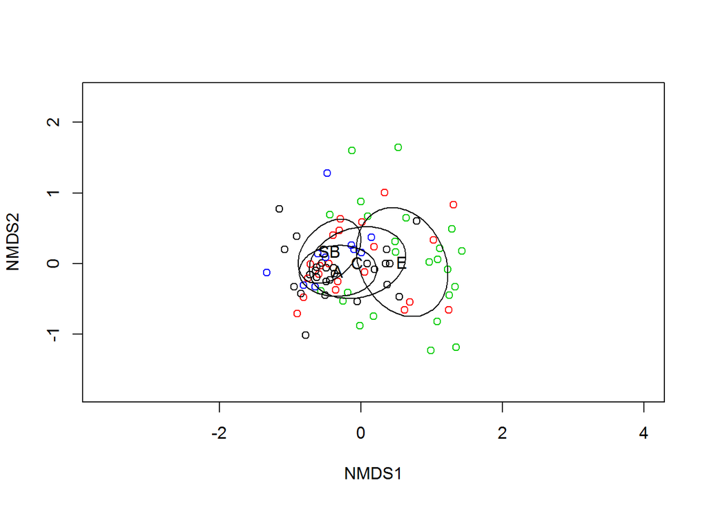

```r
plot(ghsoilmds, display = "species", type= "n")
points(ghsoilmds,display = "sites", col = as.numeric(ghsoilspecies_low$Species))
ordiellipse(ghsoilmds, ghsoilspecies_low$Species, label = TRUE)
```

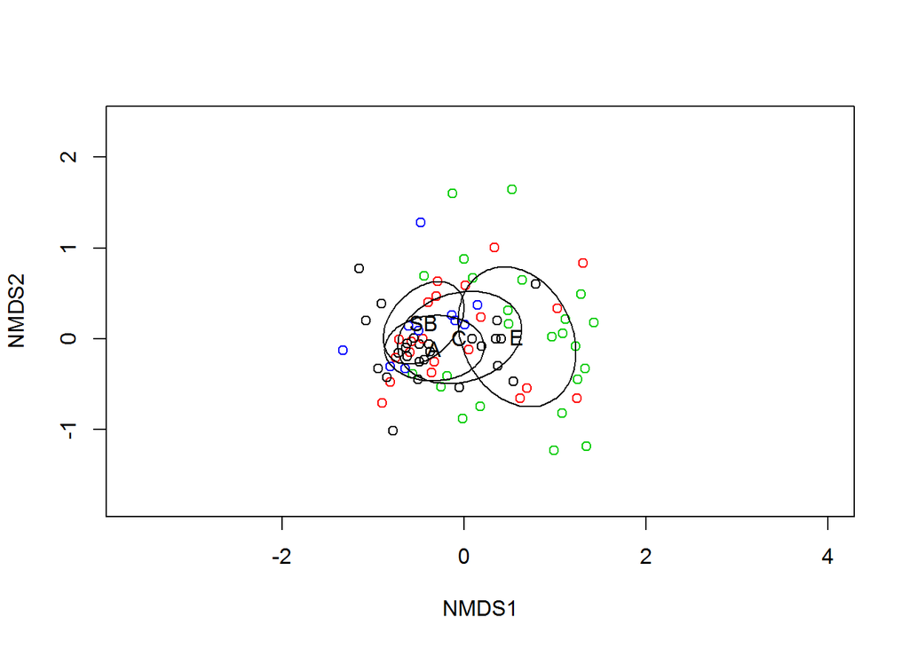

```r
plot(ghsoilmds, display = "species", type= "n")
points(ghsoilmds,display = "sites", col = as.numeric(ghsoilspecies_low$Species))
ordiellipse(ghsoilmds, ghsoilspecies_low$Species, label = TRUE)
```

```r
fit_gh16S <- adonis(ghsoilspecies_low[24:1502] ~ timepoint * Soil_type * Species, data = ghsoilspecies_low, permutations = 999)
fit_gh16S
```

```
##
## Call:
## adonis(formula = ghsoilspecies_low[24:1502] ~ timepoint * Soil_type *      Species, data = ghsoilspecies_low, permutations = 999)
##
## Permutation: free
## Number of permutations: 999
##
## Terms added sequentially (first to last)
##
##                             Df SumsOfSqs MeanSqs F.Model      R2 Pr(>F)
## timepoint                    1    2.7697 2.76967  8.9068 0.09281  0.001
## Soil_type                    1    0.9104 0.91045  2.9278 0.03051  0.001
## Species                      3    1.7153 0.57176  1.8387 0.05748  0.002
## timepoint:Soil_type          1    0.7424 0.74237  2.3873 0.02488  0.002
## timepoint:Species            3    1.3034 0.43447  1.3972 0.04368  0.019
## Soil_type:Species            3    1.1790 0.39299  1.2638 0.03951  0.066
## timepoint:Soil_type:Species  3    1.0104 0.33679  1.0830 0.03386  0.244
## Residuals                   65   20.2125 0.31096         0.67729
## Total                       80   29.8430                 1.00000
##
## timepoint                   ***
## Soil_type                   ***
## Species                     **
## timepoint:Soil_type         **
## timepoint:Species           *
## Soil_type:Species           .
## timepoint:Soil_type:Species
## Residuals
## Total
## ---
## Signif. codes:  0 '***' 0.001 '**' 0.01 '*' 0.05 '.' 0.1 ' ' 1
```

Table:

```r
library(knitr)
library(kableExtra)
```

Plot for microbial communities shifts between timepoint 1 and 2

[figure not shown]

```r
plot2 <- plot(ghsoilmds, display = "species", type= "n")
points(ghsoilmds,display = "sites", col = as.numeric(ghsoilspecies_16S_TP1$tp_species), pch = 20)
```

```r
ordiellipse(ghsoilmds, ghsoilspecies_16S_TP1$tp_species, draw = "polygon", col=1:8, border=1:8, alpha=63, label = F)
```

**looking at species effect at timepoint 2**

```r
fit_gh16S <- adonis(ghsoilspecies_16S_TP2[24:1503] ~ Soil_type + Species + Species*Soil_type, data = ghsoilspecies_16S_TP2, permutations = 999)
fit_gh16S
```

```
##
## Call:
## adonis(formula = ghsoilspecies_16S_TP2[24:1503] ~ Soil_type +      Species + Species * Soil_type, data = ghsoilspecies_16S_TP2,      permutations = 999)
##
## Permutation: free
## Number of permutations: 999
##
## Terms added sequentially (first to last)
##
##                   Df SumsOfSqs MeanSqs F.Model      R2 Pr(>F)
## Soil_type          1    0.8228 0.82283  2.3629 0.03548  0.001 ***
## Species            3    1.7979 0.59930  1.7210 0.07753  0.001 ***
## Soil_type:Species  3    1.0686 0.35621  1.0229 0.04608  0.419
## Residuals         56   19.5006 0.34822         0.84091
## Total             63   23.1899                 1.00000
## ---
## Signif. codes:  0 '***' 0.001 '**' 0.01 '*' 0.05 '.' 0.1 ' ' 1
```

## Examine at timepoint 2 and low nutrient

```
## *** No convergence -- monoMDS stopping criteria:
##     20: stress ratio > sratmax
```

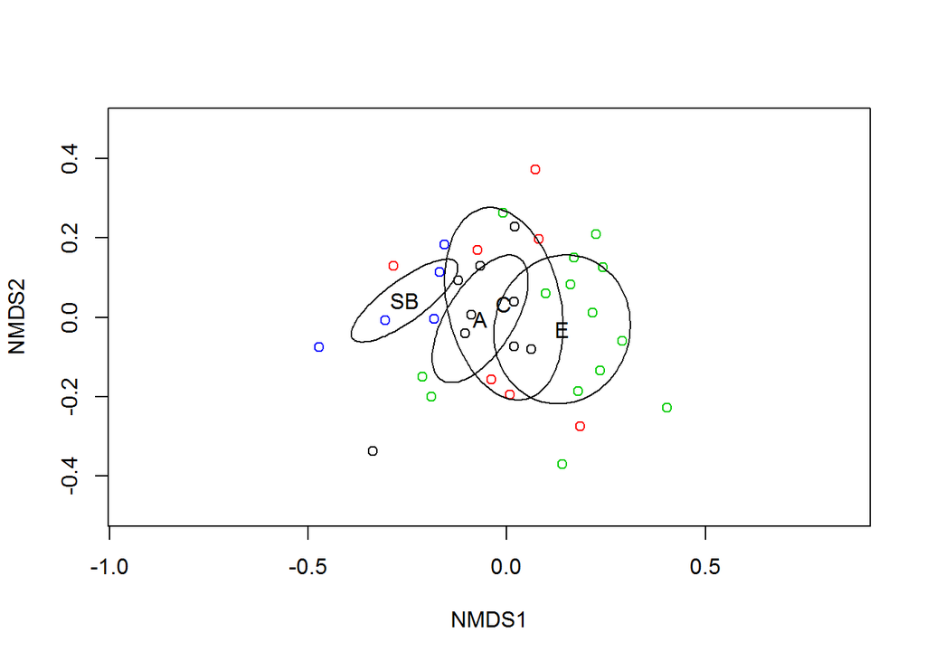

```r
fit_gh16S <- adonis(ghsoilspecies_16S_TP2[28:1225] ~ Species*Soil_type, data = ghsoilspecies_16S_TP2, permutations = 999)
fit_gh16S
```

```
##
## Call:
## adonis(formula = ghsoilspecies_16S_TP2[28:1225] ~ Species * Soil_type,      data = ghsoilspecies_16S_TP2, permutations = 999)
##
## Permutation: free
## Number of permutations: 999
##
## Terms added sequentially (first to last)
##
##                   Df SumsOfSqs MeanSqs F.Model      R2 Pr(>F)
## Species            3    1.3685 0.45615  1.2334 0.09932  0.069 .
## Soil_type          1    1.0952 1.09522  2.9614 0.07949  0.001 ***
## Species:Soil_type  3    1.3291 0.44302  1.1979 0.09646  0.094 .
## Residuals         27    9.9855 0.36983         0.72473
## Total             34   13.7783                 1.00000
## ---
## Signif. codes:  0 '***' 0.001 '**' 0.01 '*' 0.05 '.' 0.1 ' ' 1
```

## PCoA: (Work in progress)

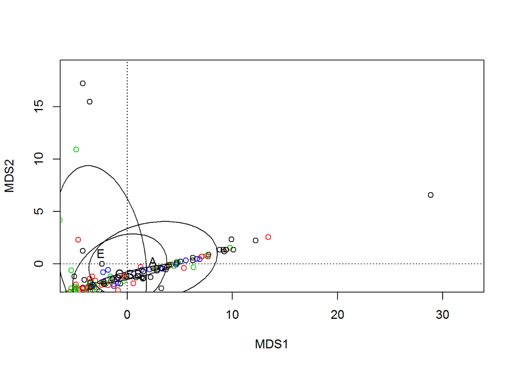

```r
ghsoilspecies_16S_PCA = subset(ghsoilspecies_16S_edited, sample_ID != 281 & sample_ID != 284)
ghsoilpco = capscale(ghsoilspecies_16S_PCA[24:1502]~1)
plot(ghsoilpco, display = "species", type= "n")
points(ghsoilpco,display = "sites", col = as.numeric(ghsoilspecies_16S_PCA$Species))
ordiellipse(ghsoilpco, ghsoilspecies_16S_PCA$Species, label = TRUE)
```

Looks like Elites are bit more varied in the microbes its associating with?? Idk…

## Now, let’s examine soil treatment effects:

```r
ghsoilspecies_16S_H <- subset(ghsoil16S, Nutrient == "Low", Timepoint = "T2")
ghsoilmds = metaMDS(ghsoilspecies_16S_H[24:1503])
```

```
## *** No convergence -- monoMDS stopping criteria:
##     20: stress ratio > sratmax
```

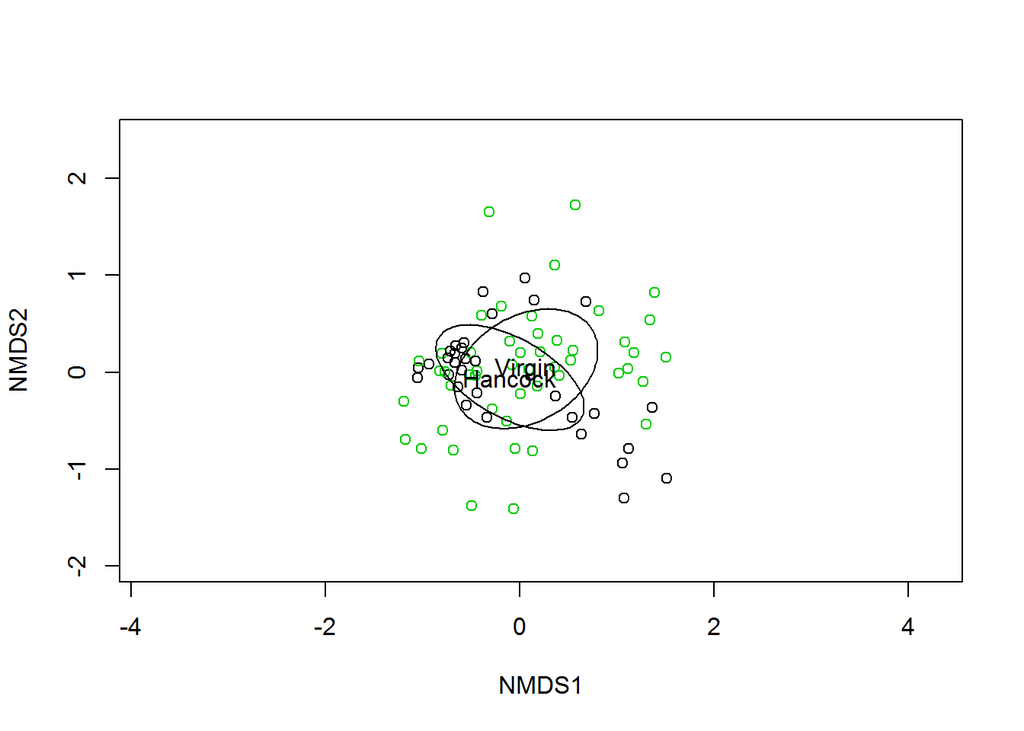

```r
plot(ghsoilmds, display = "species", type= "n")
points(ghsoilmds,display = "sites", col = as.numeric(ghsoilspecies_16S_H$Soil_type))
ordiellipse(ghsoilmds, ghsoilspecies_16S_H$Soil_type, label = TRUE)
```

```r
ghsoilspecies_16S_V <- subset(ghsoil16S, Nutrient == "Low" & Soil_type == "Virgin")
#labels(ghsoil16S)
ghsoilmds = metaMDS(ghsoilspecies_16S_V[24:1503])
```

```
## *** No convergence -- monoMDS stopping criteria:
##     20: stress ratio > sratmax
```

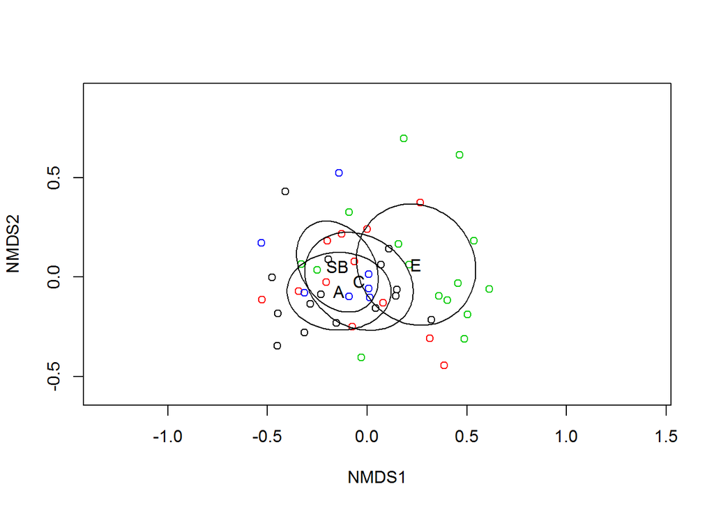

```r
plot(ghsoilmds, display = "species", type= "n")
points(ghsoilmds,display = "sites", col = as.numeric(ghsoilspecies_16S_V$Species))
ordiellipse(ghsoilmds, ghsoilspecies_16S_V$Species, label = TRUE)
```

## We now want to examine High nutrient conditions:

```r
ghsoilspecies_16S_High<- subset(ghsoil16S, Nutrient == "High")
ghsoilmds = metaMDS(ghsoilspecies_16S_High[24:1503])
```

```
## *** No convergence -- monoMDS stopping criteria:
##     20: stress ratio > sratmax
```

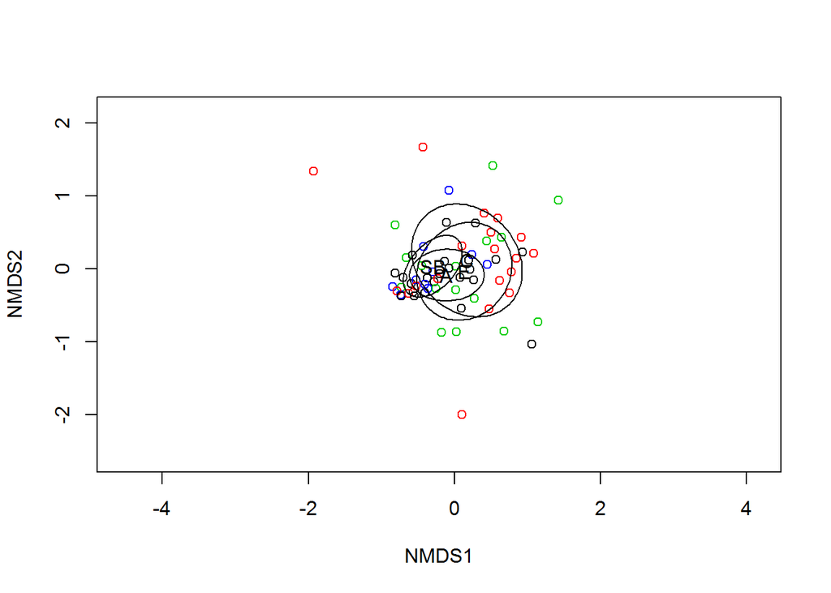

```r
plot(ghsoilmds, display = "species", type= "n")
points(ghsoilmds,display = "sites", col = as.numeric(ghsoilspecies_16S_High$Species))
ordiellipse(ghsoilmds, ghsoilspecies_16S_High$Species, label = TRUE, alpha = 100)
```

```r
a = adonis(ghsoilspecies_16S_High[,23:1230]~Soil_type*Species, data=ghsoilspecies_16S_High, perm=999)
a
```

```
##
## Call:
## adonis(formula = ghsoilspecies_16S_High[, 23:1230] ~ Soil_type *      Species, data = ghsoilspecies_16S_High, permutations = 999)
##
## Permutation: free
## Number of permutations: 999
##
## Terms added sequentially (first to last)
##
##                   Df SumsOfSqs  MeanSqs F.Model      R2 Pr(>F)
## Soil_type          1    0.0536 0.053570 0.82966 0.01195  0.513
## Species            3    0.2620 0.087340 1.35267 0.05847  0.136
## Soil_type:Species  3    0.2913 0.097110 1.50398 0.06501  0.097 .
## Residuals         60    3.8741 0.064569         0.86456
## Total             67    4.4811                  1.00000
## ---
## Signif. codes:  0 '***' 0.001 '**' 0.01 '*' 0.05 '.' 0.1 ' ' 1
```

## Timepoint 1 @ low nutrient levels

```r
ghsoilspecies_16S_TP1 <- subset(ghsoil16S, timepoint == "16S" & Nutrient == "Low")
ghsoilmds = metaMDS(ghsoilspecies_16S_TP1[24:1503])
```

```
## *** No convergence -- monoMDS stopping criteria:
##     20: stress ratio > sratmax
```

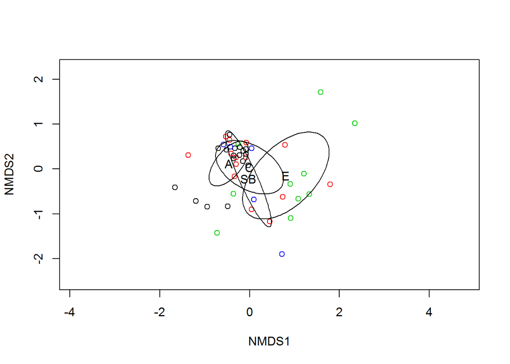

```r
plot(ghsoilmds, display = "species", type= "n")
points(ghsoilmds,display = "sites", col = as.numeric(ghsoilspecies_16S_TP1$Species))
ordiellipse(ghsoilmds, ghsoilspecies_16S_TP1$Species, label = TRUE)
```

```r
a = adonis(ghsoilspecies_16S_TP1[,24:1503]~Soil_type*Species, data=ghsoilspecies_16S_TP1, perm=999)
a
```

```
##
## Call:
## adonis(formula = ghsoilspecies_16S_TP1[, 24:1503] ~ Soil_type *      Species, data = ghsoilspecies_16S_TP1, permutations = 999)
##
## Permutation: free
## Number of permutations: 999
##
## Terms added sequentially (first to last)
##
##                   Df SumsOfSqs MeanSqs F.Model      R2 Pr(>F)
## Soil_type          1    0.7863 0.78634  2.6996 0.05486  0.002 **
## Species            3    1.3935 0.46450  1.5947 0.09722  0.009 **
## Soil_type:Species  3    1.0842 0.36139  1.2407 0.07564  0.091 .
## Residuals         38   11.0687 0.29128         0.77227
## Total             45   14.3327                 1.00000
## ---
## Signif. codes:  0 '***' 0.001 '**' 0.01 '*' 0.05 '.' 0.1 ' ' 1
```

**Timepoint 1 at High Nutrient Conditions**

```r
ghsoilspecies_16S_TP1 <- subset(ghsoil16S, timepoint == "16S" & Nutrient == "High")
ghsoilmds = metaMDS(ghsoilspecies_16S_TP1[24:1503])
```

```
## *** No convergence -- monoMDS stopping criteria:
##     20: stress ratio > sratmax
```

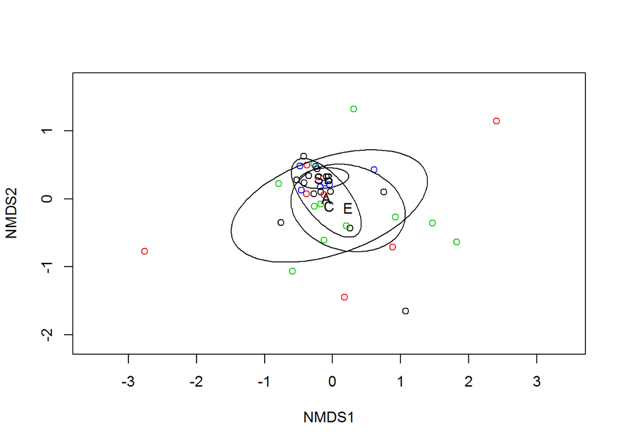

```r
plot(ghsoilmds, display = "species", type= "n")
points(ghsoilmds,display = "sites", col = as.numeric(ghsoilspecies_16S_TP1$Species))
ordiellipse(ghsoilmds, ghsoilspecies_16S_TP1$Species, label = TRUE)
```

```r
a = adonis(ghsoilspecies_16S_TP1[,24:1503]~Soil_type*Species, data=ghsoilspecies_16S_TP1, perm=999)
ghsoilspecies_16S_TP1 <- subset(ghsoil16S, timepoint == "16S" & Nutrient != "Low")
ghsoilmds = metaMDS(ghsoilspecies_16S_TP1[28:1229])
```

```
## *** No convergence -- monoMDS stopping criteria:
##      5: no. of iterations >= maxit
##     15: stress ratio > sratmax
```

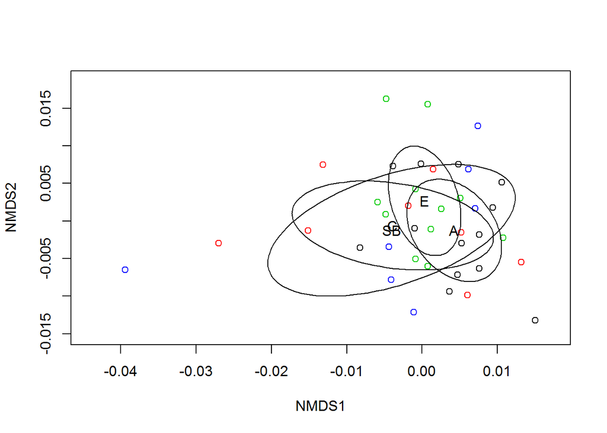

```r
plot(ghsoilmds, display = "species", type= "n")
points(ghsoilmds,display = "sites", col = as.numeric(ghsoilspecies_16S_TP1$Species))
ordiellipse(ghsoilmds, ghsoilspecies_16S_TP1$Species, label = TRUE)
```

# How about looking at how microbial communities change across time? (Work in progress…)

```r
library(tidyverse)
groups <- factor(c(rep("A-T1",17),rep("C-T1",15),rep("M-T1",11),rep("SB-T1",6),rep("A-T2",10),rep("C-T2",8),rep("M-T1",16),rep("SB-T2",6)))
```

[figure not shown]

```r
plot2 <- plot(ghsoilmds, display = "species", type= "n")
points(ghsoilmds,display = "sites", col = as.numeric(ghsoilspecies_16S_TP1$tp_species), pch = 20)
ordiellipse(ghsoilmds, ghsoilspecies_16S_TP1$tp_species, draw = "polygon", col=1:8, border=1:8, alpha=63, label = F)
legend(x="bottomleft",legend=groups)
```

# Soil Type

Looking at soil type = Prairie & Nutrient level High

```r
ghsoilspecies_16S_TP1 <- subset(ghsoil16S, Soil_type == "Virgin" & Nutrient == "High")
ghsoilmds = metaMDS(ghsoilspecies_16S_TP1[28:1229])
```

```
## *** No convergence -- monoMDS stopping criteria:
##      1: no. of iterations >= maxit
##     19: stress ratio > sratmax
```

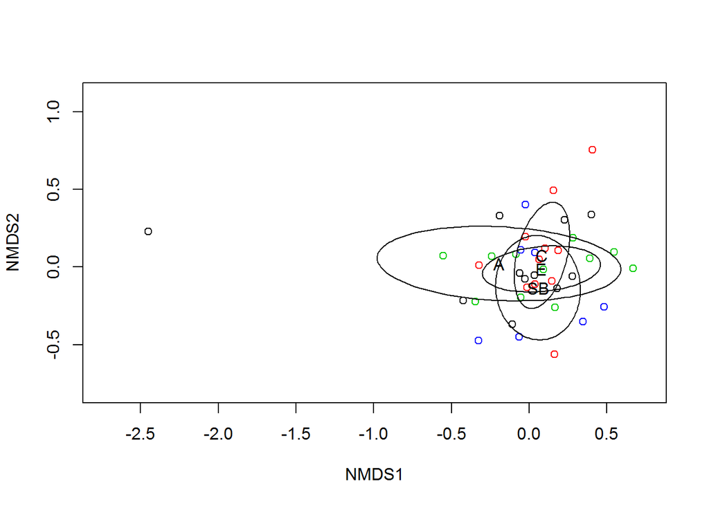

```r
plot(ghsoilmds, display = "species", type= "n")
points(ghsoilmds,display = "sites", col = as.numeric(ghsoilspecies_16S_TP1$Species))
ordiellipse(ghsoilmds, ghsoilspecies_16S_TP1$Species, label = TRUE)
```

```r
a = adonis(ghsoilspecies_16S_TP1[,24:1503]~Species, data=ghsoilspecies_16S_TP1, perm=999)
a
```

```
##
## Call:
## adonis(formula = ghsoilspecies_16S_TP1[, 24:1503] ~ Species,      data = ghsoilspecies_16S_TP1, permutations = 999)
##
## Permutation: free
## Number of permutations: 999
##
## Terms added sequentially (first to last)
##
##           Df SumsOfSqs MeanSqs F.Model      R2 Pr(>F)
## Species    3    1.0479 0.34930  1.0739 0.08214  0.293
## Residuals 36   11.7097 0.32527         0.91786
## Total     39   12.7576                 1.00000
```

Now let’s examine hancock soil:

```r
ghsoilspecies_16S_TP1 <- subset(ghsoil16S, Soil_type == "Hancock" & Nutrient == "Low")
ghsoilmds = metaMDS(ghsoilspecies_16S_TP1[28:1225])
```

```
## *** No convergence -- monoMDS stopping criteria:
##      2: no. of iterations >= maxit
##     18: stress ratio > sratmax
```

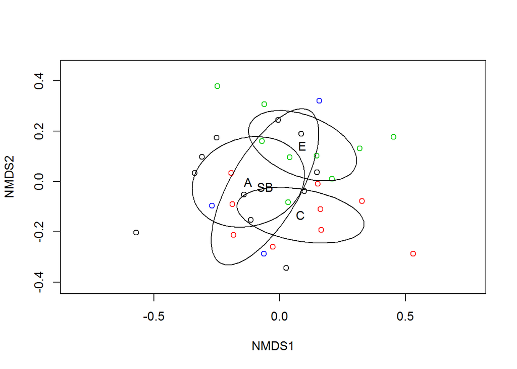

```r
plot(ghsoilmds, display = "species", type= "n")
points(ghsoilmds,display = "sites", col = as.numeric(ghsoilspecies_16S_TP1$Species))
ordiellipse(ghsoilmds, ghsoilspecies_16S_TP1$Species, label = TRUE)
```

```r
a = adonis(ghsoilspecies_16S_TP1[,28:1225]~Species, data=ghsoilspecies_16S_TP1, perm=999)
a
```

```
##
## Call:
## adonis(formula = ghsoilspecies_16S_TP1[, 28:1225] ~ Species,      data = ghsoilspecies_16S_TP1, permutations = 999)
##
## Permutation: free
## Number of permutations: 999
##
## Terms added sequentially (first to last)
##
##           Df SumsOfSqs MeanSqs F.Model     R2 Pr(>F)
## Species    3    1.5777 0.52589  1.1961 0.1136  0.035 *
## Residuals 28   12.3106 0.43967         0.8864
## Total     31   13.8883                 1.0000
## ---
## Signif. codes:  0 '***' 0.001 '**' 0.01 '*' 0.05 '.' 0.1 ' ' 1
```